# Reproducible Research: Peer Assessment 1

## Loading and preprocessing the data

```r
echo=TRUE ## Code always visible
scipen=1
Sys.setlocale("LC_TIME", "English")
```

```
## [1] "English_United States.1252"
```

```r
data<-read.csv("activity.csv")
str(data)
```

```
## 'data.frame':    17568 obs. of  3 variables:
##  $ steps   : int  NA NA NA NA NA NA NA NA NA NA ...
##  $ date    : Factor w/ 61 levels "2012-10-01","2012-10-02",..: 1 1 1 1 1 1 1 1 1 1 ...
##  $ interval: int  0 5 10 15 20 25 30 35 40 45 ...
```

```r
head(data)
```

```
##   steps       date interval
## 1    NA 2012-10-01        0
## 2    NA 2012-10-01        5
## 3    NA 2012-10-01       10
## 4    NA 2012-10-01       15
## 5    NA 2012-10-01       20
## 6    NA 2012-10-01       25
```

```r
library(ggplot2)
```

## What is mean total number of steps taken per day?

- Calculate the total number of steps taken per day

```r
sumSteps<-aggregate(steps~date,data=data, FUN=sum, na.rm=TRUE)
```

- Make a histogram of the total number of steps taken each day and calculate and report the mean and median of the total number of steps taken per day

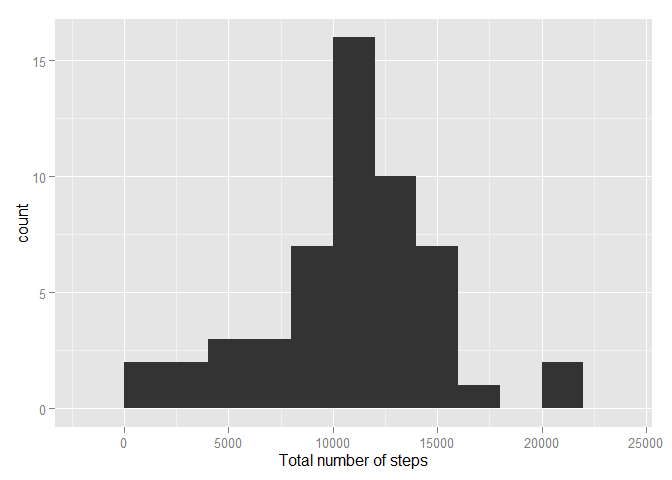

```r
qplot(steps,data=sumSteps,binwidth=2000)+xlab("Total number of steps")
```

```r
mean(sumSteps$steps,na.rm=TRUE)
```

```
## [1] 10766.19
```

```r
median(sumSteps$steps,na.rm=TRUE)
```

```
## [1] 10765
```

## What is the average daily activity pattern?

- Make a time series plot of the 5-minute interval (x-axis) and the average number of steps taken, averaged across all days and show the 5-minute interval which contains the maximun number of steps

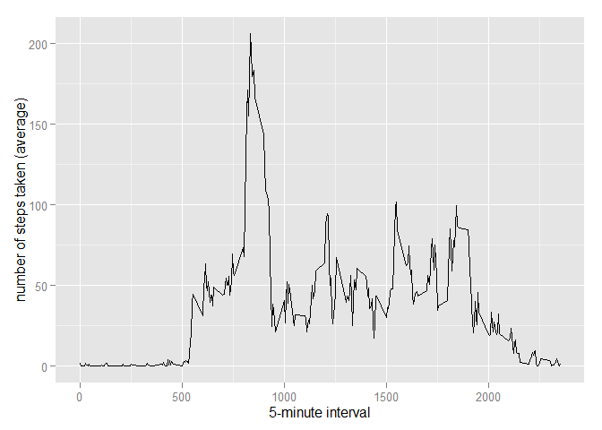

```r
avgSteps<-aggregate(steps~interval,data=data,mean,na.rm=TRUE)
names(avgSteps)[2] <- "meanOfSteps"
g <- ggplot(avgSteps, aes(x = interval, y =meanOfSteps))
g + geom_line()+xlab("5-minute interval")+ylab("number of steps taken (average)")
```

```r
avgSteps[which.max( avgSteps[,2] ),]
```

```
##     interval meanOfSteps
## 104      835    206.1698
```

## Imputing missing values

- Calculate and report the total number of missing values in the dataset

```r
sum(is.na(data$steps))
```

```
## [1] 2304
```

- Devise a strategy for filling in all the missing values in the dataset: I use the mean for 5-minute interval as strategy for filling missing values
- Create a new dataset that is equal to the original dataset but with the missing data filled in.

```r
data2<-data
for(i in 1:nrow(data2)){
        if(is.na(data2$steps[i])){
        data2$steps[i]<-avgSteps[which(data2$interval[i]==avgSteps$interval),]$meanOfSteps
        }
}
sum(is.na(data2))
```

```
## [1] 0
```

```r
head(data2)
```

```
##       steps       date interval
## 1 1.7169811 2012-10-01        0
## 2 0.3396226 2012-10-01        5
## 3 0.1320755 2012-10-01       10
## 4 0.1509434 2012-10-01       15
## 5 0.0754717 2012-10-01       20
## 6 2.0943396 2012-10-01       25
```

- Make a histogram of the total number of steps taken each day and Calculate and report the mean and median total number of steps taken per day

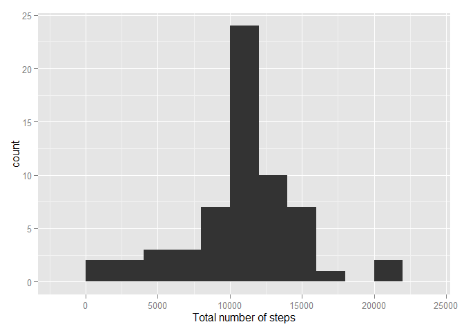

```r
sumSteps2<-aggregate(steps~date,data=data2, FUN=sum)
qplot(steps,data=sumSteps2,binwidth=2000)+xlab("Total number of steps")
```

```r
mean(sumSteps2$steps)
```

```
## [1] 10766.19
```

```r
median(sumSteps2$steps)
```

```
## [1] 10766.19
```

- Do this values differ from the estimates from the first part of the assigment?

```r
meanSteps<-c(mean(sumSteps$steps),mean(sumSteps2$steps),(mean(sumSteps$steps)-mean(sumSteps2$steps)))
medianSteps<-c(median(sumSteps$steps),median(sumSteps2$steps),(median(sumSteps$steps)-median(sumSteps2$steps)))
x<-rbind(meanSteps,medianSteps)
colnames(x)<-c("Old value","New value","Difference")
x
```

```
##             Old value New value Difference
## meanSteps    10766.19  10766.19   0.000000
## medianSteps  10765.00  10766.19  -1.188679
```

## Are there differences in activity patterns between weekdays and weekends?

- Create a new factor variable in the dataset with two levels - “weekday” and “weekend” indicating wheter a given data is a weekday or weekend day.

```r
dateTime<-paste(as.Date(data2$date),data2$Time)
data2$DateTime<-as.POSIXct(dateTime)
data2$wkday<-weekdays(data2$DateTime)
data2$weekdays[data2$wkday==c("Saturday","Sunday")]<-"Weekend"
data2$weekdays[data2$wkday!=c("Saturday","Sunday")]<-"Weekday"
head(data2)
```

```
##       steps       date interval   DateTime  wkday weekdays
## 1 1.7169811 2012-10-01        0 2012-10-01 Monday  Weekday
## 2 0.3396226 2012-10-01        5 2012-10-01 Monday  Weekday
## 3 0.1320755 2012-10-01       10 2012-10-01 Monday  Weekday
## 4 0.1509434 2012-10-01       15 2012-10-01 Monday  Weekday
## 5 0.0754717 2012-10-01       20 2012-10-01 Monday  Weekday
## 6 2.0943396 2012-10-01       25 2012-10-01 Monday  Weekday
```

- Make a panel plot containing a time series plot of the 5-minute interval (x-axis) and the average number of steps taken, averaged across all weekday days or weekend days (y-axis)

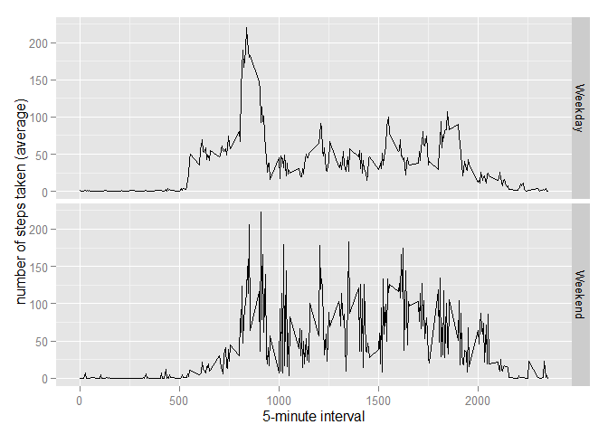

```r
avgSteps2<-aggregate(data2$steps,
                     list(interval=as.numeric(as.character(data2$interval)),
                          weekdays=data2$weekdays),
                     FUN="mean")
names(avgSteps2)[3]<-"meanOfSteps"
g <- ggplot(avgSteps2, aes(x = interval, y =meanOfSteps))
g + geom_line()+xlab("5-minute interval")+ylab("number of steps taken (average)")+facet_grid(weekdays~.)
```